# Multiple Regression and Diagnostics

## Agenda

1. A/B Testing Review (and upgrade)
2. Multiple Regression
3. Interactions and Uplift Modeling
4. Regression Diagnostics

## But first…

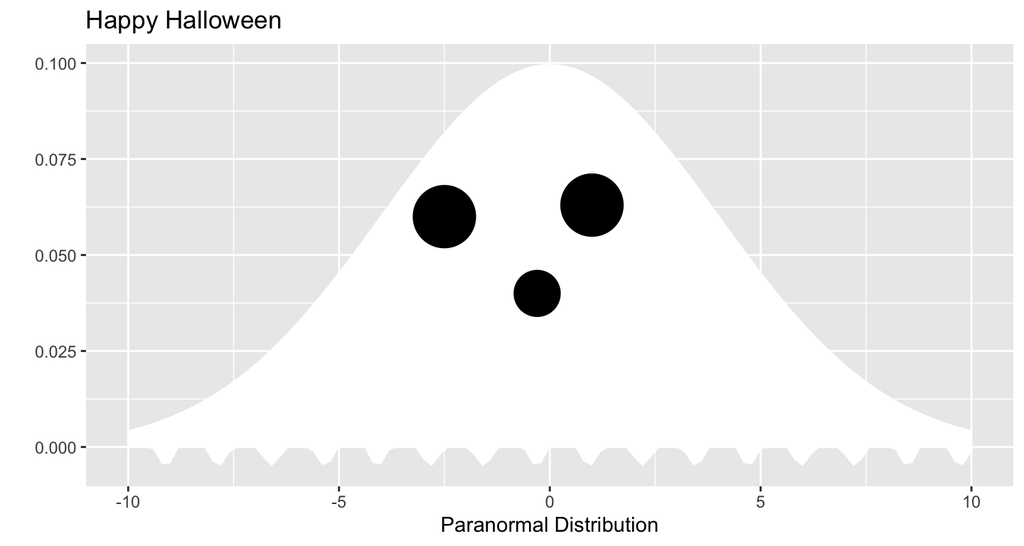

## A/B testing review (and upgrade)

## What did we learn last time?

1. Randomization checks
2. Difference in proportions
3. Difference in means
4. How to calculate sample size (power)

## Randomization checks

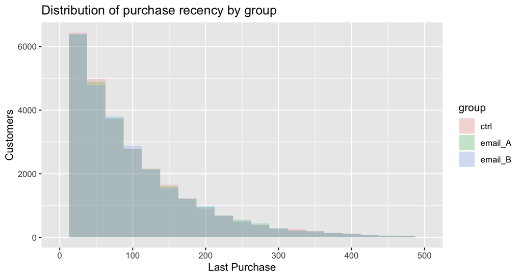

```r
d %>% filter(past_purch > 0) %>%
ggplot(aes(x=last_purch, fill=group)) +
  geom_histogram(binwidth = 25, alpha=0.2, position="identity") +
  xlim(0, 500) +
  xlab("Last Purchase") + ylab("Customers") +
  labs(title="Distribution of purchase recency by group")
```

## Testing differences in proportions

For categorical outcomes

```r
success <- d %>%
  filter(group!="ctrl") %>%
  group_by(group,click) %>%
  count() %>%
  filter(click==1)
trials <- d %>%
  filter(group!="ctrl") %>%
  count(group)

prop.test(success$n,trials$n)
```

```
##
##  2-sample test for equality of proportions with continuity
##  correction
##
## data:  success$n out of trials$n
## X-squared = 367.2, df = 1, p-value < 2.2e-16
## alternative hypothesis: two.sided
## 95 percent confidence interval:
##  0.03754391 0.04612615
## sample estimates:
##     prop 1     prop 2
## 0.13152992 0.08969489
```

## Testing differences in means

For continuous variables

```r
d <- d %>%
  mutate(email = group %in% c("email_B","email_A"))
t.test(purch ~ email, data=d)
```

```
##
##  Welch Two Sample t-test
##
## data:  purch by email
## t = -5.4485, df = 89037, p-value = 5.093e-08
## alternative hypothesis: true difference in means is not equal to 0
## 95 percent confidence interval:
##  -1.9417432 -0.9143263
## sample estimates:
## mean in group FALSE  mean in group TRUE
##            12.32166            13.74970
```

## (Upgrade) experiments within experiments

- Consider the customers who have made a purchase in the last 60-ish days.
- Within that subset, customers were randomly assigned to recieve email A, email B or no email.
- So, we can analyze the data for a subgroup as it’s own test by slicing down and then re-analyzing.
- However, we will only have enough sample in the subgroup if our initial test is big enough.

## Exercise

1. Create a new variable called ‘recent’ that equals 1 (TRUE) if last_purch < median(last_purch)
2. create bar graphs that show the difference in 1) opens, and 2) clicks
3. by the newly created variable

## Solution opens

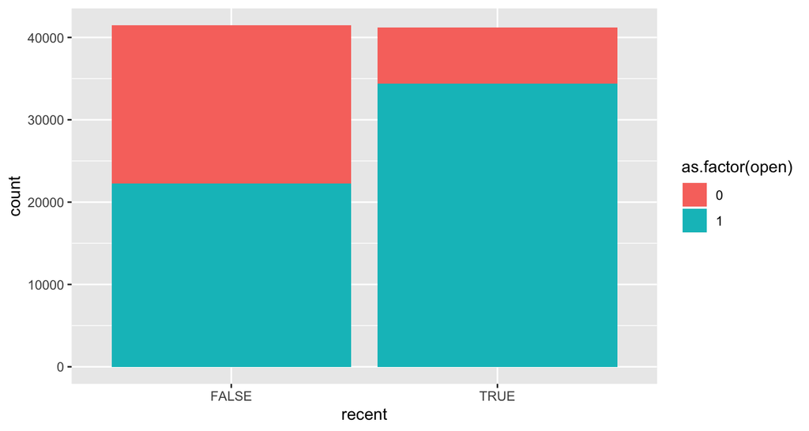

```r
d <- d %>% mutate(recent=(last_purch<summary(d$last_purch)[['Median']]))
d %>%
  filter(group != "ctrl") %>%
  ggplot(aes(x=recent, fill=as.factor(open)))+
    geom_bar()
```

## Solution clicks

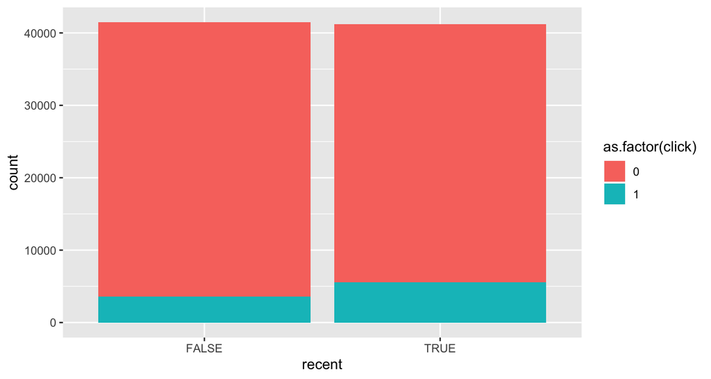

```r
d %>%
  filter(group != "ctrl") %>%
  ggplot(aes(x=recent, fill=as.factor(click)))+
    geom_bar()
```

## Exercise

**Question:** Does the email campaign have more of an effect on the purchases of recent shoppers? If so, what is the difference?  
*Hint:* Start by creating a new variable called ‘email’ that equals 1 if group != ‘ctrl’

## Solution

```r
d <- d %>% mutate(email = (group!="ctrl"))
d %>%
  group_by(recent, email) %>%
  summarise(purchases = mean(purch), opens=mean(open), clicks=mean(click)) %>%
  knitr::kable() %>%
  kable_styling(full_width = TRUE, bootstrap_options = c("striped", "hover"))
```

| recent | email | purchases | opens | clicks |
| --- | --- | --- | --- | --- |
| FALSE | FALSE | 6.038011 | 0.0000000 | 0.0000000 |
| FALSE | TRUE | 6.969084 | 0.5360432 | 0.0857563 |
| TRUE | FALSE | 18.606531 | 0.0000000 | 0.0000000 |
| TRUE | TRUE | 20.579380 | 0.8358184 | 0.1356484 |

Looks like emails increase purchases by about $2 for recent shoppers, but only about $1 for aged shoppers.

## Testing the difference for aged

```r
t.test(purch ~ email, data=d %>% filter(!recent))
```

```
##
##  Welch Two Sample t-test
##
## data:  purch by email
## t = -3.539, df = 45112, p-value = 0.0004021
## alternative hypothesis: true difference in means is not equal to 0
## 95 percent confidence interval:
##  -1.4467326 -0.4154129
## sample estimates:
## mean in group FALSE  mean in group TRUE
##            6.038011            6.969084
```

## Testing the difference for recent

```r
t.test(purch ~ email, data=d %>% filter(recent))
```

```
##
##  Welch Two Sample t-test
##
## data:  purch by email
## t = -4.4129, df = 44388, p-value = 1.022e-05
## alternative hypothesis: true difference in means is not equal to 0
## 95 percent confidence interval:
##  -2.849100 -1.096596
## sample estimates:
## mean in group FALSE  mean in group TRUE
##            18.60653            20.57938
```

## We slice based on baseline variables

Anyone who keeps historic data on customers or visitors has lots of baseline variables available for slicing and dicing:

- website visits (to particular parts of the site)
- sign-ups
- geographic location
- source
- past purchase (by category)
- recency
- frequency

## Exercise

**Question:** Does the email campaign have more of an effect on the behavior of those that purchased syrah in the past?

```r
summary(d$syrah > 0)
```

```
##    Mode   FALSE    TRUE
## logical   88359   35629
```

## Solution (table)

```r
d %>%
  group_by(syrah>0, email) %>%
  summarise(purchases = mean(purch), opens=mean(open), clicks=mean(click)) %>%
  kable() %>%
  kable_styling(full_width = TRUE, bootstrap_options = c("striped", "hover"))
```

| syrah > 0 | email | purchases | opens | clicks |
| --- | --- | --- | --- | --- |
| FALSE | FALSE | 11.65547 | 0.0000000 | 0.0000000 |
| FALSE | TRUE | 12.84414 | 0.6567638 | 0.0997248 |
| TRUE | FALSE | 13.98036 | 0.0000000 | 0.0000000 |
| TRUE | TRUE | 15.99102 | 0.7562432 | 0.1375599 |

## Repeated significance testing

Slicing and dicing means you will run many significance tests.

You may remember from intro stats that 1 in 20 significance tests at 95% confidence will be significant, when there is no effect. You will get false positives, especially when slicing and dicing.

When you think you’ve found a golden ticket, re-test before betting the company.

## Slicing and dicing: Summary

Slicing and dicing will reveal two things about subgroups of customers.

1. Subgroups will vary in how much they engage in behaviors
   - Recent buyers tend to have higher average purchases in the future
2. Subgroups vary in how they respond to treatments
   - Recent buyers are more affected by the email

## Multiple regression

## Heterogeneous treatment effects

“Experiments are used because they provide credible estimates of the effect of an intervention for a sample population. But underlying this average effect for a sample may be **substantial variation in how particular respondents respond to treatments**: there may be **heterogeneous treatment effects**.”

– Athey and Imbens, 2015

## Heterogeneous treatment effects and targeting

Businesses should be interested in heterogeneous treatment effects when there is opportunity to apply different treatments to each subgroup (ie targeting).

email -> high potential for targeting

website -> less potential for targeting

## Analyzing experiments with regression

We use a **regression model** to define a relationship between the response (\(y\)) and the treatment (\(x\)).

\(y = a + b \times x + \varepsilon\)

The model literally says that we get the average response by multiplying the treatment indicator (\(x\)) by \(b\) and adding that to \(a\). When we fit a model, we use data to estimate \(a\) and \(b\).

In R, we can shorthand the model equation with an R formula:

```r
m1 <- lm(purch ~ email, data=d)
get_regression_table(m1)
```

```
## # A tibble: 2 x 7
##   term      estimate std_error statistic p_value lower_ci upper_ci
##   <chr>        <dbl>     <dbl>     <dbl>   <dbl>    <dbl>    <dbl>
## 1 intercept    12.3      0.22       56.0       0     11.9    12.8
## 2 emailTRUE     1.43     0.269       5.3       0      0.9     1.96
```

## Regression versus significance test

```r
get_regression_table(m1)
```

```
## # A tibble: 2 x 7
##   term      estimate std_error statistic p_value lower_ci upper_ci
##   <chr>        <dbl>     <dbl>     <dbl>   <dbl>    <dbl>    <dbl>
## 1 intercept    12.3      0.22       56.0       0     11.9    12.8
## 2 emailTRUE     1.43     0.269       5.3       0      0.9     1.96
```

```r
t.test(purch ~ email, data=d, var.equal=TRUE)
```

```
##
##  Two Sample t-test
##
## data:  purch by email
## t = -5.2996, df = 123986, p-value = 1.162e-07
## alternative hypothesis: true difference in means is not equal to 0
## 95 percent confidence interval:
##  -1.956172 -0.899897
## sample estimates:
## mean in group FALSE  mean in group TRUE
##            12.32166            13.74970
```

## Regression versus significance tests

If you like regression, you can use regression to analyze all your tests.

If you don’t like regression, you should try it because it gives you the ability to pull in baseline variables. This is sometimes called “regression correction.”

## Model including baseline variables

```r
m2 <- lm(purch ~ email + recent, data=d)
get_regression_table(m2)
```

```
## # A tibble: 3 x 7
##   term       estimate std_error statistic p_value lower_ci upper_ci
##   <chr>         <dbl>     <dbl>     <dbl>   <dbl>    <dbl>    <dbl>
## 1 intercept      5.69     0.251     22.7        0    5.20      6.18
## 2 emailTRUE      1.45     0.266      5.45       0    0.929     1.97
## 3 recentTRUE    13.3      0.251     52.8        0   12.8      13.8
```

Aged customers in the control group purchased on average $5.69 in the 30-days after the email was sent. Recent customers in the control group purchased an additional $13.26. The average effect of the email was $1.45.

## Model with continuous baseline variable

```r
lm(purch ~ email + last_purch, data=d) %>%
  get_regression_table()
```

```
## # A tibble: 3 x 7
##   term       estimate std_error statistic p_value lower_ci upper_ci
##   <chr>         <dbl>     <dbl>     <dbl>   <dbl>    <dbl>    <dbl>
## 1 intercept    19.0       0.251     75.5        0   18.5     19.5
## 2 emailTRUE     1.42      0.266      5.32       0    0.896    1.94
## 3 last_purch   -0.074     0.001    -52.8        0   -0.077   -0.071
```

Adding covariates increases the likelihood of finding significant effects. Why?

## Interactions and uplift modeling

## Incorporating heterogeneous treatment effects

To incorporate heterogeneous treatment effects, we need an **interaction** between the treatment effect (\(x\)) and a baseline variable (\(z\)).

When we interact two terms, we are defining a model that multiplies the two terms:

\(y = a + b x + c z + d (x z) + \varepsilon\)

The R formula for this model is:

`purch ~ email + recent + email:recent`

…or…

`purch ~ email*recent`

## Incorporating heterogeneous treatment effects

```r
m3 <- lm(purch ~ email + recent + email:recent, data=d)
get_regression_table(m3)
```

```
## # A tibble: 4 x 7
##   term               estimate std_error statistic p_value lower_ci upper_ci
##   <chr>                 <dbl>     <dbl>     <dbl>   <dbl>    <dbl>    <dbl>
## 1 intercept             6.04      0.308     19.6    0        5.44      6.64
## 2 emailTRUE             0.931     0.377      2.47   0.013    0.193     1.67
## 3 recentTRUE           12.6       0.435     28.9    0       11.7      13.4
## 4 emailTRUE:recentT…    1.04      0.533      1.96   0.051   -0.003     2.09
```

## An uplift model for purchase amount

An uplift model is a regression model that incorporates many baseline variables.

```r
m4 <- lm(purch ~ email*recent + email*(past_purch > 50) + email*(visits > 3) +
                 email*(chard > 0) + email*(sav_blanc>0) + email*(syrah>0) + email*(cab>0),
         data=d)
get_regression_table(m4)
```

```
## # A tibble: 16 x 7
##    term              estimate std_error statistic p_value lower_ci upper_ci
##    <chr>                <dbl>     <dbl>     <dbl>   <dbl>    <dbl>    <dbl>
##  1 intercept           -0.315     0.596    -0.528   0.597   -1.48     0.854
##  2 emailTRUE           -0.527     0.729    -0.723   0.47    -1.96     0.902
##  3 recentTRUE          12.5       0.432    28.9     0       11.6     13.3
##  4 past_purch > 50T…    3.08      0.654     4.71    0        1.80     4.36
##  5 visits > 3TRUE       1.44      0.566     2.54    0.011    0.327    2.55
##  6 chard > 0TRUE        4.88      0.573     8.51    0        3.75     6
##  7 sav_blanc > 0TRUE    4.62      0.574     8.05    0        3.49     5.74
##  8 syrah > 0TRUE        1.36      0.517     2.63    0.008    0.348    2.38
##  9 cab > 0TRUE          0.475     0.509     0.932   0.351   -0.523    1.47
## 10 emailTRUE:recent…    1.15      0.53      2.17    0.03     0.114    2.19
## 11 emailTRUE:past_p…    0.04      0.801     0.05    0.96    -1.53     1.61
## 12 emailTRUE:visits…    0.901     0.692     1.30    0.193   -0.456    2.26
## 13 emailTRUE:chard …    0.570     0.702     0.813   0.416   -0.805    1.95
## 14 emailTRUE:sav_bl…    1.42      0.701     2.02    0.044    0.041    2.79
## 15 emailTRUE:syrah …    0.702     0.634     1.11    0.268   -0.541    1.94
## 16 emailTRUE:cab > …   -0.49      0.623    -0.787   0.431   -1.71     0.731
```

## Scoring customers with an uplift model

If you have someone who wasn’t in the test, but you know their baseline variables, you can use an uplift model to predict likely treatment effect.

```r
new_cust <- slice(d,5) %>% select(chard, sav_blanc,syrah, cab, past_purch,recent,visits)
new_cust
```

```
## # A tibble: 1 x 7
##   chard sav_blanc syrah   cab past_purch recent visits
##   <dbl>     <dbl> <dbl> <dbl>      <dbl> <lgl>   <dbl>
## 1  427.     1222.     0     0      1649. TRUE        9
```

```r
(pred <- predict(m4, cbind(email=c(TRUE, FALSE), new_cust)))
```

```
##        1        2
## 29.74036 26.18863
```

```r
(lift <- pred[1] - pred[2])
```

```
##        1
## 3.551724
```

This random customer is predicted to buy $29.74 if they get an email or $26.18 without, for a uplift of $3.55.

## Scoring for another (worse) customer

```r
new_cust <- slice(d,25) %>% select(chard, sav_blanc,syrah, cab, past_purch,recent,visits)
new_cust
```

```
## # A tibble: 1 x 7
##   chard sav_blanc syrah   cab past_purch recent visits
##   <dbl>     <dbl> <dbl> <dbl>      <dbl> <lgl>   <dbl>
## 1     0         0  191.     0       191. FALSE       6
```

```r
(pred <- predict(m4, cbind(email=c(TRUE, FALSE), new_cust)))
```

```
##        1        2
## 6.680073 5.564312
```

```r
(lift <- pred[1] - pred[2])
```

```
##        1
## 1.115761
```

## Why uplift modeling?

If treatments are costly (eg catalogs, discounts), then we should target customers that we predict will have a positive effect that exceeds costs.

## Regression diagnostics

## Sum of squared residuals

1. Find the residuals (error terms)
2. Square them
3. Add them all up

```r
d <- d %>% mutate(lpurch=log(purch+1))
m <- lm(lpurch ~ email*recent, data=d)
get_regression_points(m) %>%
  mutate(sq_residuals = residual^2) %>%
  summarize(ssr = sum(sq_residuals))
```

```
## # A tibble: 1 x 1
##       ssr
##     <dbl>
## 1 286696.
```

## R-squared

\(R^2=1-\frac{var(resid)}{var(y)}\)

*Definition:* the proportion of the total variation in the outcome variable y that the model explains.  
**Why is var(y) guaranteed to be >= var(residuals)?**  
*Note:* \(var(s^2)=\frac{\sum(x_i-\bar{x})^2}{n-1}\)

## RMSE

1. **E**rror = residuals
2. **S**quare each error
3. **M**ean of that squared error
4. **R**oot of that mean squared error

### Roughly, the quality of a model’s predictions

## Example

```r
m <- lm(lpurch ~ email*recent, data=d)
get_regression_summaries(m)
```

```
## # A tibble: 1 x 8
##   r_squared adj_r_squared   mse  rmse sigma statistic p_value    df
##       <dbl>         <dbl> <dbl> <dbl> <dbl>     <dbl>   <dbl> <dbl>
## 1     0.065         0.065  2.31  1.52  1.52     2886.       0     4
```

## Cross Validation - test/train

Creating the train and test sets

```r
# Randomly shuffle order of rows:
d_shuffled <- d %>%
  sample_frac(size = 1, replace = FALSE)
# Split into train and test:
train <- d_shuffled %>%
  slice(1:100000)
test <- d_shuffled %>%
  slice(100001:123988)

m <- lm(log(purch+1) ~ email*recent, data=train)
get_regression_table(m)
```

```
## # A tibble: 4 x 7
##   term               estimate std_error statistic p_value lower_ci upper_ci
##   <chr>                 <dbl>     <dbl>     <dbl>   <dbl>    <dbl>    <dbl>
## 1 intercept             0.367     0.012     31.1    0        0.344    0.39
## 2 emailTRUE             0.049     0.014      3.37   0.001    0.02     0.077
## 3 recentTRUE            0.756     0.017     45.4    0        0.723    0.789
## 4 emailTRUE:recentT…    0.064     0.02       3.13   0.002    0.024    0.104
```

## Cross Validation - validate

```r
get_regression_points(m, newdata = test) %>%
  mutate(sq_residuals = residual^2) %>%
  summarize(rmse = sqrt(mean(sq_residuals)))
```

```
## # A tibble: 1 x 1
##    rmse
##   <dbl>
## 1  47.0
```

## Bonus: Continuous by categorical interactions

```r
c <- lm(purch ~ email*last_purch, data=d)
get_regression_table(c)
```

```
## # A tibble: 4 x 7
##   term               estimate std_error statistic p_value lower_ci upper_ci
##   <chr>                 <dbl>     <dbl>     <dbl>   <dbl>    <dbl>    <dbl>
## 1 intercept            18.4       0.307     60.0    0       17.8     19.0
## 2 emailTRUE             2.22      0.377      5.88   0        1.48     2.96
## 3 last_purch           -0.068     0.002    -28.2    0       -0.073   -0.063
## 4 emailTRUE:last_pu…   -0.009     0.003     -3      0.003   -0.015   -0.003
```